# **Raport Analityczny: Federacja Sportowa Chomików**

HYDRA

2026-02-01

# 1 **Wstęp**

Niniejszy raport stanowi analizę danych Międzynarodowej Federacji Wyścigów Chomików. Celem dokumentu jest ocena wyników sportowych, kondycji finansowej federacji oraz analiza trendów w chomiczym sporcie na podstawie zgromadzonych **500** rekordów chomików, i **24** rekordów zawodów.

# 2 **Profil Zawodnika i Wyniki Sportowe**

## 2.1 **Analiza Mistrzów i Wyników Sportowych**

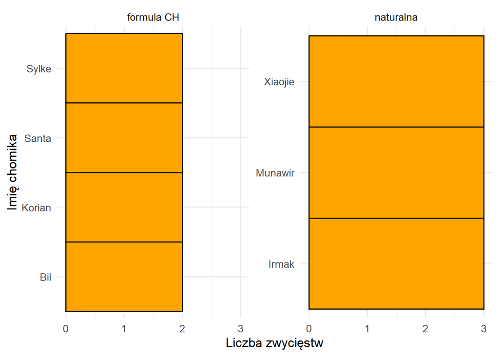

W formule Ch mistrzem jest **Korian, Bil, Sylke, Santa**, osiągając **2** zwycięstw.

W formule sportów naturalnych mistrzem jest **Xiaojie, Munawir, Irmak**, osiągając **3** zwycięstw.

## 2.2 **Szczyt Kariery i Wiek Zawodników**

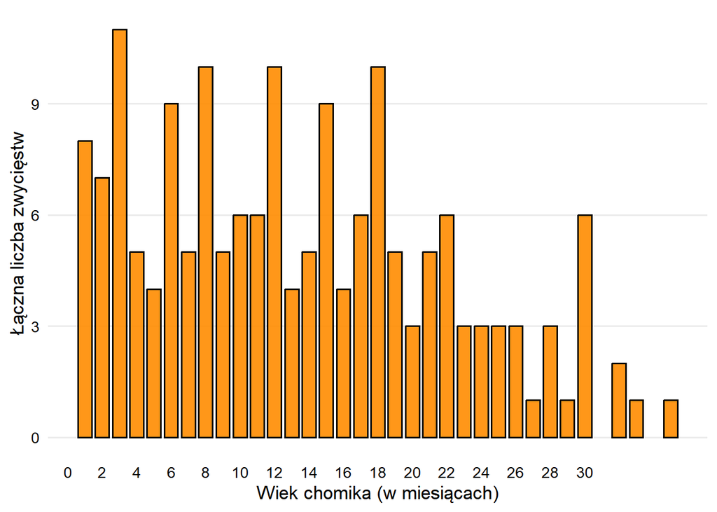

Statystyki wskazują, że szczyt formy jest zależny od wieku. Najwięcej zwycięstw osiągają chomiki w wieku **3** miesięcy. Z kolei najmniej sukcesów na koncie mają zawodnicy w wieku **27, 29, 33, 35** miesięcy.

## 2.3 **Wpływ wagi na wyniki – czy lżejsze chomiki są szybsze?**

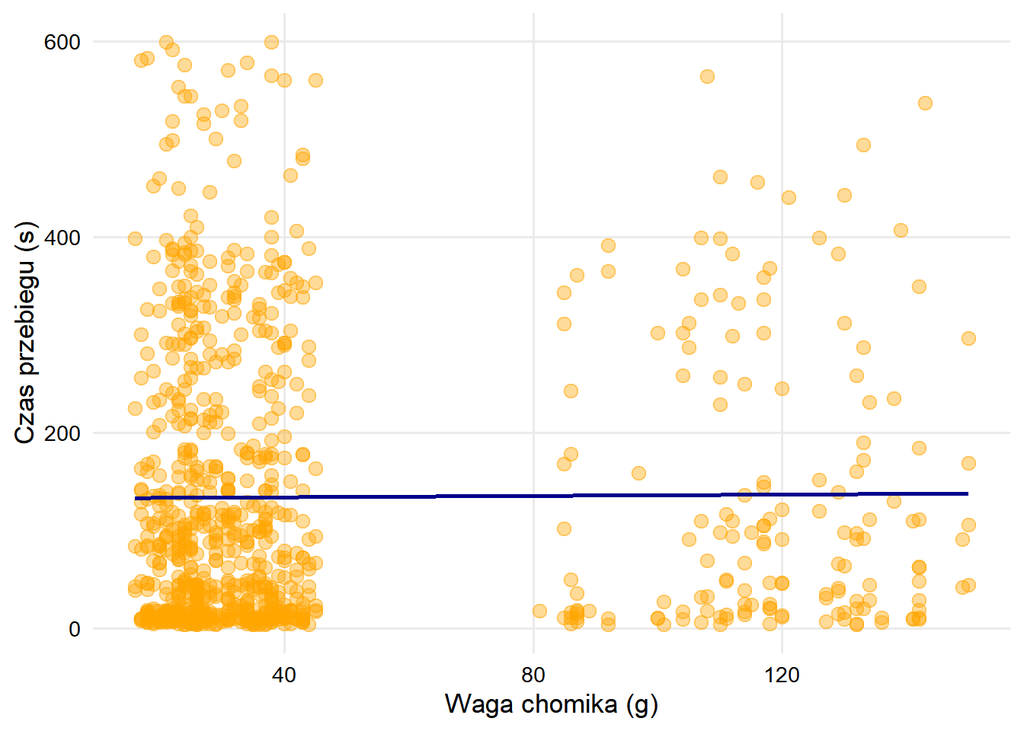

Niebieska linia na tym wykresie to linia trendu. Pokazuje ona ogólną zależność dla wszystkich zawodników, ignorując pojedyncze odstępstwa. Jeśli linia wznosi się do góry (↗), oznacza to, że im cięższy jest chomik, tym dłuższy czas osiąga (czyli cięższe chomiki są wolniejsze). Jeśli linia opada w dół (↘), oznacza to, że im cięższy jest chomik, tym krótszy czas osiąga (czyli cięższe chomiki są szybsze).Im bardziej stroma jest ta linia, tym silniejszy jest wpływ wagi na wynik biegu.

## 2.4 **Jaka jest skala dopingu w chomiczym sporcie?**

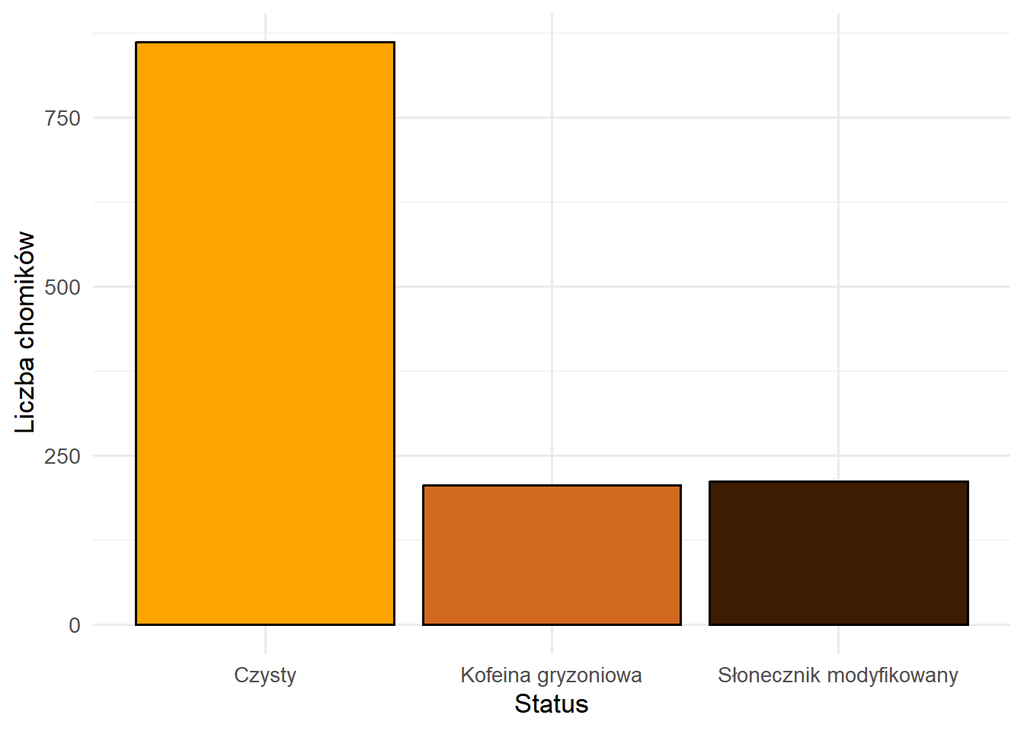

W ramach dbałości o czystość sportu przeprowadzono łącznie **1279** kontroli. Wyniki wykazały, że **861** tetsów było negatywnych. Odnotowano przypadki stosowania dopingu (**418** przypadków). Najczęściej wykrywaną substancją zakazaną była **Słonecznik modyfikowany**.

# 3 **Zasięg i Rozwój Federacji**

## 3.1 **Trendy i Popularność Sportu**

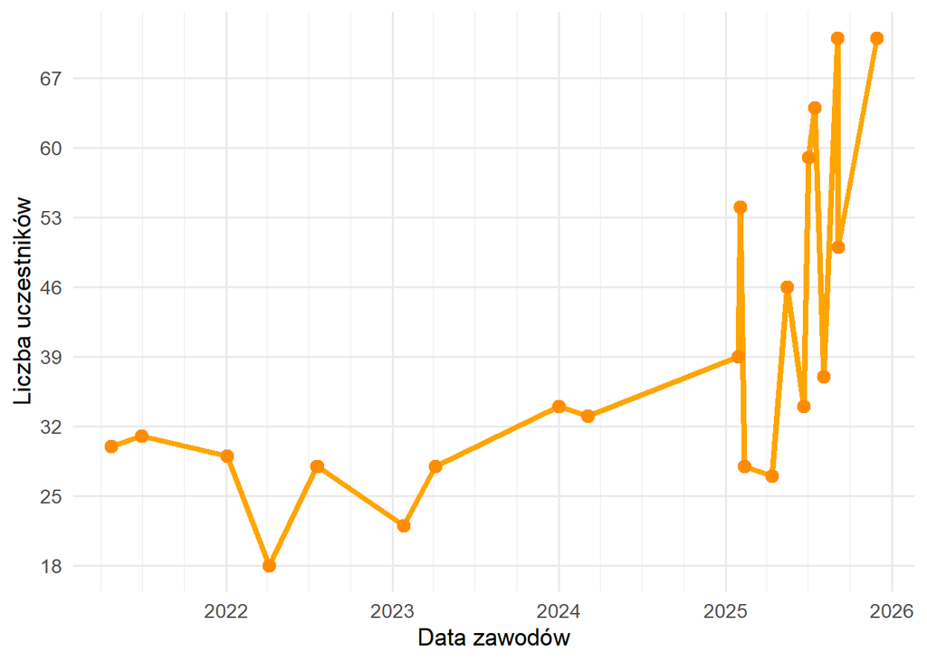

Szczyt popularności chomiczego sportu przypadł na dzień **2025-11-29**. W zawodach wzięła wówczas udział rekordowa liczba **71** uczestników.

## 3.2 **Gdzie chomiczy sport jest najpopularniejszy?**

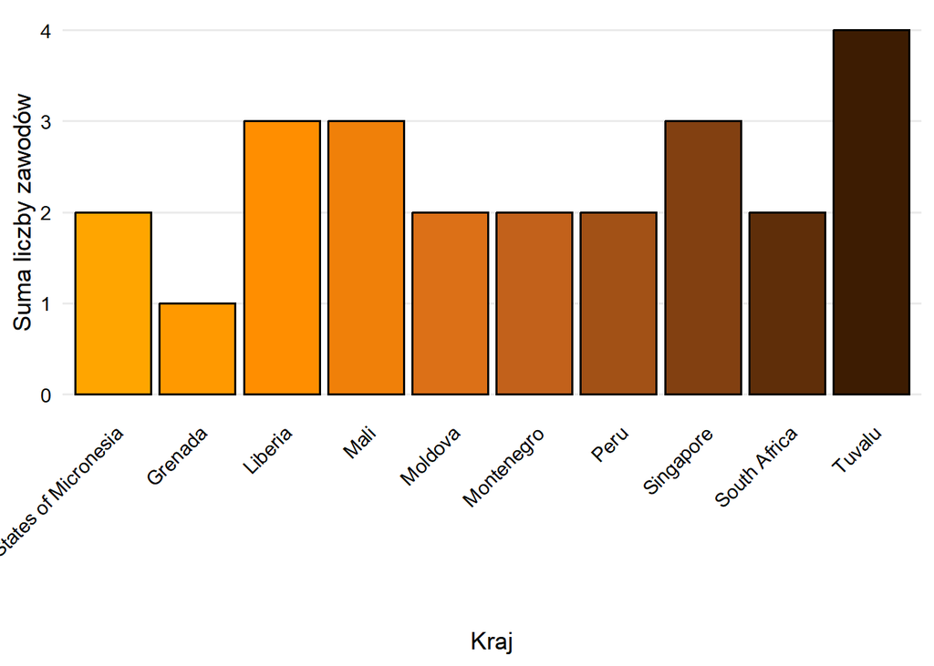

Liderem w organizowaniu zawodów jest **Tuvalu**, gdzie zorganizowano ( /po) **4** oficjalnych zawodów.

# 4 **Finanse i Partnerzy Biznesowi**

## 4.1 **Kondycja Finansowa i Atrakcyjność Rynkowa**

### 4.1.1 **Atrakcyjność Rynkowa: Portfolio Sponsorów**

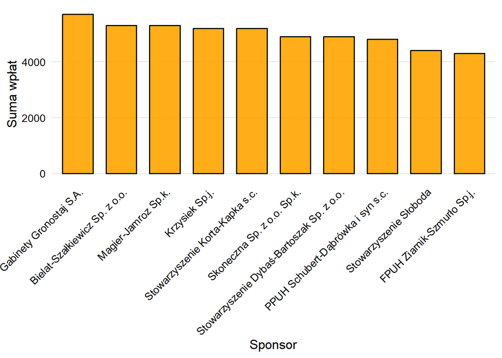

Strategicznym partnerem federacji jest firma **Gabinety Gronostaj S.A.**, której łączny wkład finansowy wyniósł ( /po) **5 700** PLN.Łącznie od wszystkich sponsorów pozyskano fundusze w wysokości **50 000** PLN.

### 4.1.2 **Atrakcyjność Rynkowa: Wydatki na Kadry**

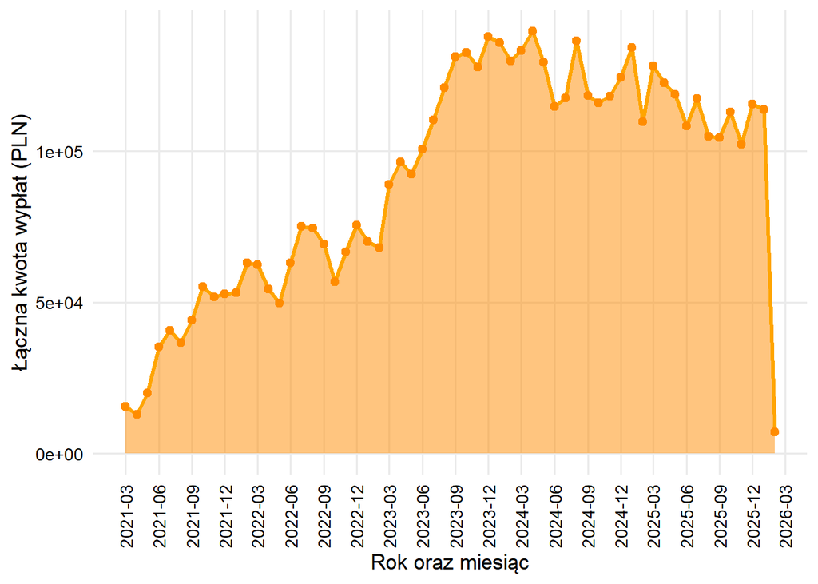

Największe obciążenie budżetu odnotowano w miesiącu **2024-04-01**, kiedy to suma wypłat osiągnęła szczytowy poziom **139 596** PLN.

## 4.2 **Który sponsor ma pod opieką chomiki z największą liczbą zwycięstw.**

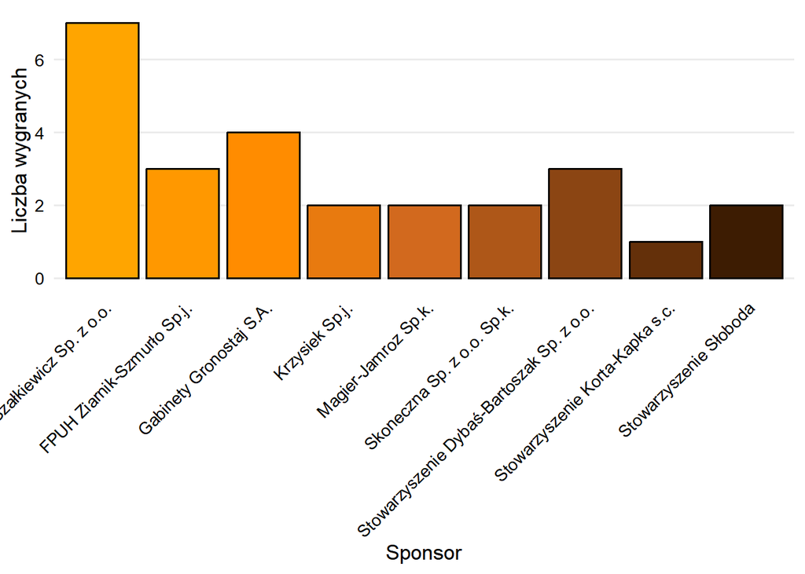

Największą liczbą zwycięstw w historii mogą pochwalić się: **Bielat-Szałkiewicz Sp. z o.o.**. Sponsorzy ci doprowadzili swoich zawodników do podium ( /po) **7** razy.